# fig_s1_flowchart

Sanmi Adenaiye

5/27/2021

Compute numbers for a flow chart that describes our study cohort.

# import complete datasets

```r
allsamples <- read.csv(file="./../../source_data/StopCOVIDsamples.csv",stringsAsFactors=F)
cov_pcr_sera <- readRDS("./../../analytical_cleaned_datasets/cov_pcr_sera_20210805.RDS")
pcrscreen <- cov_pcr_sera[["pcr_screen"]]
qpcr <- cov_pcr_sera[["qpcr_allsamples"]]
demo <- cov_pcr_sera[["demohist"]]
sero <- cov_pcr_sera[["sero1"]]
```

## 1. Weekly screening

Volunteers in weekly saliva testing cohort (N) Screened samples (n) Last samples 6/1/2021

```r
drivebysaliva <- pcrscreen %>% filter(redcap_event_name=="driveby_saliva_arm_1" & sample_date <=as.Date("2021-06-01",origin="1970-01-01"))
drivebysaliva %>% unique() %>% nrow() # number of driveby-screened saliva samples
```

```
## [1] 4938
```

```r
drivebysaliva$study_id %>% unique() %>% length() # number of driveby screened participants
```

```
## [1] 238
```

```r
# store these in a list
flowchartlist <- list()
flowchartlist[["salivacohortsize"]] <- c("Weekly Saliva Testing Cohort",
                                         paste0("(N = ",drivebysaliva$study_id %>% unique() %>% length(),", weekly samples = ",drivebysaliva %>% unique() %>% nrow(),")"))

# samples X subject
drivebysaliva %>% group_by(study_id) %>% summarize(`no of samples provided`=n()) %>% group_by(`no of samples provided`) %>% summarize(`no of subjects`=n())
```

```
## # A tibble: 53 x 2
##    `no of samples provided` `no of subjects`
##                       <int>            <int>
##  1                        1               17
##  2                        2                4
##  3                        3               10
##  4                        4                9
##  5                        5                7
##  6                        6                8
##  7                        7                3
##  8                        8                5
##  9                        9                6
## 10                       10                9
## # … with 43 more rows
```

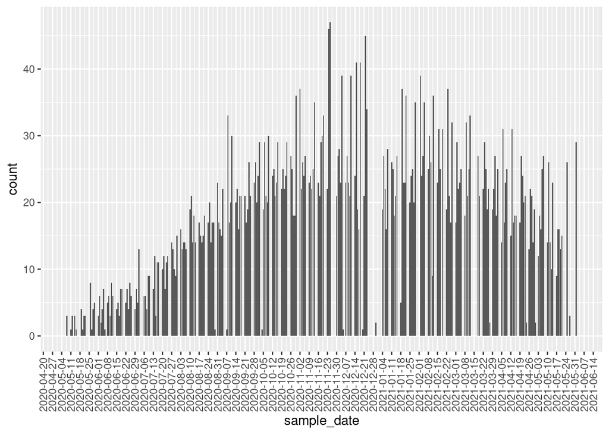

```r
# samples per week
drivebysaliva %>% ggplot(
  aes(x=sample_date)) +
  geom_bar(stat = "count") +
  scale_x_date(breaks = "1 week") +
  theme(axis.text.x = element_text(angle = 90, vjust = 0.5, hjust=1)
)
```

```r
# Earliest screening date in this dataset
min(drivebysaliva$sample_date)
```

```
## [1] "2020-05-08"
```

```r
# Last screening date in this dataset
max(drivebysaliva$sample_date)
```

```
## [1] "2021-06-01"
```

```r
# first case detection date
ctscreencols <- c("ct_ngene_screen","ct_sgene_screen","ct_orf1ab_screen")
pcrscreen1 <- pcrscreen %>% select(sample_date,all_of(ctscreencols))
pcrscreen1$pos <- pcrscreen1 %>% apply(c(1,2),function(x) {x<40}) %>% apply(1,function(x) {sum(x)>=2})
pcrscreen1 %>% filter(pos) %>% pull(sample_date) %>% min()
```

```
## [1] "2020-06-06"
```

```r
flowchartlist[["dates"]] <- c(
  "Start and stop and detection dates",
  paste0(
    "The first saliva sample screening occurred on ",
    min(drivebysaliva$sample_date),
    " and the last saliva screening occurred on ",
    max(drivebysaliva$sample_date),
    ". The first detection date was ",
    pcrscreen1 %>% filter(pos) %>% pull(sample_date) %>% min(),
    ".
"
  )
)
```

The first saliva sample screening occurred on May 8, 2020 and the last saliva screening occurred on June 1, 2021. The first detection date was June 6, 2020.

arm 1 = screening arm 2 = direct cases arm 3 = contacts

## 1a. Weekly screening volunteers to had a postive on a drivebysaliva

```r
drivebysaliva$pos <- drivebysaliva[,ctscreencols] %>%
  apply(c(1,2),function(x) {x<40}) %>%
  apply(1,function(x) {sum(x)>=2})
drivebysaliva <- drivebysaliva %>% group_by(pos)
# CDC's criteria for these primers requires that at least two out of three wells have a detection to call it "positive"

drivebysaliva$pos33 <- drivebysaliva[,ctscreencols] %>%
  apply(c(1,2),function(x) {x<=33}) %>%
  apply(1,function(x) {sum(x)>=2})
# look at ct <= 33 as cut off for trace detections

# "Number of screening saliva samples that were positive:"
table((drivebysaliva$pos))
```

```
##
## FALSE  TRUE
##  4931     7
```

```r
drivebysalivapos40subjs <- drivebysaliva %>% filter(pos) %>% pull(study_id) %>% unique() %>% sort()
drivebysalivapos33subjs <-  drivebysaliva %>% filter(pos33) %>% pull(study_id) %>% unique() %>% sort()
drivebysalivapos40subjs %>% subset(!(. %in% drivebysalivapos33subjs))
```

```
## [1] "350"
```

```r
# if we apply <=33 criterion for 2 wells, we lose subject 350
```

```r
pos_driveby <- drivebysaliva %>% filter(pos)
pos_driveby_subj <- unique(pos_driveby$study_id)

# Number of positive driveby subjects (nb: 120 was pos on two consecutive samples)
length(pos_driveby_subj)
```

```
## [1] 6
```

Visits by people with pos screening saliva. Get all pcrscreen data for people with pos driveby saliva sample and collect these saliva samples in a new dataframe.

```r
pos_driveby_allother <- pcrscreen %>% filter((study_id %in% pos_driveby_subj) & redcap_event_name!="driveby_saliva_arm_1")
table(pos_driveby_allother$redcap_event_name)
```

```
##
##      ir_followup_arm_1 shedding_initial_arm_1  shedding_repeat_arm_1
##                      1                      9                      9
```

```r
# Number of people enrolled based on positive saliva weekly screening
pos_driveby_allother %>% filter(redcap_event_name=="shedding_initial_arm_1") %>% distinct(study_id, sample_date) %>% nrow()
```

```
## [1] 5
```

```r
pos_driveby_subj %>% subset(!(. %in% pos_driveby_allother$study_id))
```

```
## [1] "350"
```

```r
# one participant (350) was not counted as positive due to weak Ct>33 and suspicious curves

flowchartlist[["salivapositives"]] <- c("Cohort Member with Positive Saliva",paste0("N = ",pos_driveby_allother %>% filter(redcap_event_name=="shedding_initial_arm_1") %>% distinct(study_id, sample_date) %>% nrow()))
```

```r
# did they all give breath samples?
arm1breathsamples <- allsamples %>% filter((study_id %in% pos_driveby_allother$study_id) & grepl("G-II|G2",sample_type))
arm1breathsubjs <- arm1breathsamples$study_id %>% unique() %>% sort()
arm1breathsubjs
```

```
## [1] 144 222 446
```

```r
# only the three positive ones happened to give breath samples
pos_driveby_allother$study_id %>% subset(!(. %in% arm1breathsubjs)) %>% unique() %>% sort()
```

```
## [1] "120" "326"
```

```r
# 120 and 326 did the shedding visit but did not give G-II samples, due to time & accessibility respectively
```

```r
pos_driveby_case_v1 <- pos_driveby_allother %>% filter(redcap_event_name=="shedding_initial_arm_1")
pos_driveby_case_v1$pos_case <- pos_driveby_case_v1[,ctscreencols] %>%
  apply(c(1,2),function(x) {x<40}) %>%
  apply(1,function(x) {sum(x)>=2})
pos_driveby_case_v1 <- pos_driveby_case_v1 %>% group_by(pos_case)

#Number of positive cases enrolled based on drive by saliva screening
pos_driveby_case_v1_summary <- pos_driveby_case_v1 %>% summarize(n=length(unique(study_id)))
pos_driveby_case_v1_summary
```

```
## # A tibble: 2 x 2
##   pos_case     n
##   <lgl>    <int>
## 1 FALSE        2
## 2 TRUE         3
```

```r
pos_driveby_case_sid <- pos_driveby_case_v1 %>% filter(pos_case) %>%  pull(study_id) %>% unique()  #saving the 3 ids

flowchartlist[["salivawithoutg2"]] <- c("Did Not Give G-II Samples",paste0("N = ",pos_driveby_case_v1_summary %>% filter(!pos_case) %>% pull(n)))
flowchartlist[["salivawithg2"]] <- c("Gave G-II Samples",paste0("N = ",pos_driveby_case_v1_summary %>% filter(pos_case) %>% pull(n)))
flowchartlist[["salivaposmtsal"]] <- c("Positive on MTS/Saliva at case visit",paste0("N = ",pos_driveby_case_v1_summary %>% filter(pos_case) %>% pull(n)))
```

## 2. Contacts

Volunteer contacts of cases (enrolled as contacts) Number of screening visits done on contacts Tested positive in our lab  
Provided G-II samples

```r
pcrscreen %>% group_by(redcap_event_name) %>% summarize(n=length(unique(study_id)))
```

```
## # A tibble: 16 x 2
##    redcap_event_name            n
##    <chr>                    <int>
##  1 contact_home_sampl_arm_1     1
##  2 contact_home_sampl_arm_3    10
##  3 contact_initial_arm_1        9
##  4 contact_initial_arm_3       48
##  5 contact_repeat_arm_1         6
##  6 contact_repeat_arm_3        34
##  7 driveby_saliva_arm_1       251
##  8 ir_followup_arm_1            1
##  9 ir_followup_arm_2            6
## 10 ir_followup_arm_3            3
## 11 shedding_initial_arm_1       6
## 12 shedding_initial_arm_2      55
## 13 shedding_initial_arm_3      18
## 14 shedding_repeat_arm_1        3
## 15 shedding_repeat_arm_2       31
## 16 shedding_repeat_arm_3       13
```

Save all events with the arm_3 tag. These represents all events involving subjects who enrolled as contacts. By selecting on arm_3 we get them regardless if they were escalated to a case at what would have been a first contact visit. All contacts also include people who originally enrolled in arm_1 in addition to those in arm_3. So, we want to combine these two groups.

```r
# all contact sampling events
contacts <- pcrscreen %>% filter(grepl("contact_",redcap_event_name))
contacts_arm_1 <- pcrscreen %>% filter(grepl("contact_initial_arm_1",redcap_event_name))
contacts_arm_3 <- pcrscreen %>% filter(grepl("contact_initial_arm_3",redcap_event_name))
all_arm_3 <- pcrscreen%>% filter(grepl("arm_3",redcap_event_name))

# Number of subjects who enrolled as contacts:
# all subjects who provided contact visits of some sort
length(unique(contacts$study_id))
```

```
## [1] 58
```

all subjects who enrolled as contacts of cases arm 1

```r
contact_visited_sid <- unique(contacts$study_id)
length(unique(contacts_arm_1$study_id))
```

```
## [1] 9
```

all subjects with init contact visit who enrolled as contacts of cases arm 3

```r
length(unique(contacts_arm_3$study_id))
```

```
## [1] 48
```

all subjects who enrolled as contacts of cases arm 3 regardless of doing contact visits

```r
length(unique(all_arm_3$study_id))
```

```
## [1] 53
```

all contacts regardless of route into the study

```r
allcontactstotal <-length(unique(c(contacts$study_id,all_arm_3$study_id)))
allcontactstotal
```

```
## [1] 62
```

```r
all_contacts_sid <- unique(c(contacts$study_id,all_arm_3$study_id))
all_contacts <- pcrscreen %>% filter(study_id %in% all_contacts_sid)
```

contacts who escalated to cases w/o doing a visit were still entered via arm 3 therefore, we increase the number of counted contact visits by these four to account for their being screened based on symptoms into case visits at their first encounter

```r
setdiff(all_contacts_sid,contact_visited_sid) %>% sort()
```

```
## [1] "243" "391" "400" "471"
```

Identify study_id in contacts not having an initial visit.

```r
setdiff(unique(contacts$study_id),c(unique(contacts_arm_1$study_id),unique(contacts_arm_3$study_id)))
```

```
## [1] "441"
```

NB: study_id == “441” did an initial shedding visit, was negative and then did contact_repeat visits.

### What events/visits did these people participate in?

Note that each record in contacts is for each sample that was obtained.

```r
contacts %>% filter(study_id==486) %>% select(1:5,sample_type)
```

```
##    tac_id study_id sample_date        redcap_event_name redcap_repeat_instance
## 1    5502      486  2021-04-30     contact_repeat_arm_3                      6
## 2    5529      486  2021-04-30     contact_repeat_arm_3                      6
## 3    5526      486  2021-04-29 contact_home_sampl_arm_3                      4
## 4    5527      486  2021-04-29 contact_home_sampl_arm_3                      4
## 5    5520      486  2021-04-28     contact_repeat_arm_3                      5
## 6    5522      486  2021-04-28     contact_repeat_arm_3                      5
## 7    5509      486  2021-04-27 contact_home_sampl_arm_3                      3
## 8    5511      486  2021-04-27 contact_home_sampl_arm_3                      3
## 9    5506      486  2021-04-26     contact_repeat_arm_3                      4
## 10   5508      486  2021-04-26     contact_repeat_arm_3                      4
## 11   5496      486  2021-04-24 contact_home_sampl_arm_3                      2
## 12   5497      486  2021-04-24 contact_home_sampl_arm_3                      2
## 13   5489      486  2021-04-23     contact_repeat_arm_3                      3
## 14   5492      486  2021-04-23     contact_repeat_arm_3                      3
```

[output cut: 31 more lines]

Subject 486 had 2 sampling events on 4/30

Filter contact visits from these events  
Then select unique subject-day (randomly picking a sample_type.) This will count the number of contact visits held

```r
# subject-contact visit, ie. the  number of contact screening visits
all_contact_visits<-contacts%>%
  distinct(study_id,sample_date,.keep_all = T)

# number of contact visits coded as contact visits
num_contact_screening_visits <- all_contact_visits %>% nrow()
num_contact_screening_visits
```

```
## [1] 214
```

```r
length(unique(all_contact_visits$study_id)) #all subjects who participated in contact visits
```

```
## [1] 58
```

```r
all_shedding_init_arm_3 <- pcrscreen %>% filter(grepl("shedding_initial_arm_3",redcap_event_name))
#Number of people enrolled case contacts who did an initial shedding visit

length(unique(all_shedding_init_arm_3$study_id))
```

```
## [1] 18
```

```r
#What events did people enrolled as contacts do?
all_contacts %>% group_by(redcap_event_name) %>% summarize(n=length(unique(study_id)))
```

```
## # A tibble: 10 x 2
##    redcap_event_name            n
##    <chr>                    <int>
##  1 contact_home_sampl_arm_1     1
##  2 contact_home_sampl_arm_3    10
##  3 contact_initial_arm_1        9
##  4 contact_initial_arm_3       48
##  5 contact_repeat_arm_1         6
##  6 contact_repeat_arm_3        34
##  7 driveby_saliva_arm_1         9
##  8 ir_followup_arm_3            3
##  9 shedding_initial_arm_3      18
## 10 shedding_repeat_arm_3       13
```

Finding number of subjects not in both contacts and initial shedding arm 3.

```r
setdiff(unique(all_shedding_init_arm_3$study_id),unique(contacts$study_id)) %>% length()
```

```
## [1] 4
```

```r
# these 4 subjects though enrolled as contacts of cases, did not do a contact visit. They did case visits (confirmed in REDCap)
```

```r
setdiff(unique(all_shedding_init_arm_3$study_id),unique(contacts$study_id))
```

```
## [1] "471" "400" "391" "243"
```

```r
shed_no_contact <- setdiff(unique(all_shedding_init_arm_3$study_id),unique(contacts$study_id))
# these cases included in addition to the above a person who was escalated to a case at first encounter, but was negative and then followed as a contact.
```

```r
setdiff(unique(all_shedding_init_arm_3$study_id),unique(contacts_arm_3$study_id)) %>% sort()
```

```
## [1] "243" "391" "400" "441" "471"
```

```r
shed_no_contact_init <-setdiff(unique(all_shedding_init_arm_3$study_id),unique(contacts_arm_3$study_id))
```

```r
setdiff(shed_no_contact_init,shed_no_contact)
```

```
## [1] "441"
```

```r
flowchartlist[["contactsize"]] <- c("Volunteer Contacts of COVID-19 Cases",
                                    paste0("(N = ",allcontactstotal,", screening test-days = ",num_contact_screening_visits + length(shed_no_contact_init),")"))
```

Of the 62 subjects who enrolled as contacts, 4 of them did not do actual contact visits. These 4 subjects were thought to be cases based on symptoms and history and escalated to shedding initial visits immediately at first encounter. Also the initial visit for study_id 441 was not counted as a screening visit, because that person was also escalated to shedding visit on first encounter. None of the people enrolled as contact from arm_1 became positive or were escalated to a shedding visit based on symptoms.

So, the total number of contact screening visits is actually 214 + 5 = 219.

## 2a. Contacts turned positive

```r
# implement 2-well criterion

contacts_pcr_pos <- all_contacts
contacts_pcr_pos$pos <- contacts_pcr_pos[,ctscreencols] %>% apply(c(1,2),function(x) {x<40}) %>% apply(1,function(x) {sum(x)>=2})
contacts_pcr_pos <- contacts_pcr_pos %>% filter(pos)

contactspos33 <- all_contacts
contactspos33$pos <- contactspos33[,ctscreencols] %>% apply(c(1,2),function(x) {x<=33}) %>% apply(1,function(x) {sum(x)>=2})
contactspcr_pos33_sid <- contactspos33 %>% filter(pos) %>% pull(study_id) %>% unique() %>% sort()

contacts_pcr_pos_sid <- unique(contacts_pcr_pos$study_id)
length(contacts_pcr_pos_sid)
```

```
## [1] 19
```

```r
contacts_pcr_pos_sid %>% subset(!(. %in% contactspcr_pos33_sid))
```

```
## [1] "436"
```

```r
# if we apply <=33 criterion for 2 wells, we lose subject 436

contacts_pcr_pos_sid <- unique(contacts_pcr_pos$study_id)
length(contacts_pcr_pos_sid)
```

```
## [1] 19
```

```r
flowchartlist[["poscontacts"]] <- c("Contact with Positive Screening",paste0("N = ",length(contacts_pcr_pos_sid)))
```

There were 19 subjects (including 436 and 458) who tested positive having entered via arm 3, including the 4 escalated to shedding visits based on symptoms and who tested positive. It doesn’t include the cases from arm 1.

## 3. Participants enrolled directly as cases (arm 2)

Volunteer confirmed cases (enrolled as cases) Tested positive in our lab  
Provided G-II samples

```r
pcrscreen %>% group_by(redcap_event_name) %>% summarize(n=length(unique(study_id)))
```

```
## # A tibble: 16 x 2
##    redcap_event_name            n
##    <chr>                    <int>
##  1 contact_home_sampl_arm_1     1
##  2 contact_home_sampl_arm_3    10
##  3 contact_initial_arm_1        9
##  4 contact_initial_arm_3       48
##  5 contact_repeat_arm_1         6
##  6 contact_repeat_arm_3        34
##  7 driveby_saliva_arm_1       251
##  8 ir_followup_arm_1            1
##  9 ir_followup_arm_2            6
## 10 ir_followup_arm_3            3
## 11 shedding_initial_arm_1       6
## 12 shedding_initial_arm_2      55
## 13 shedding_initial_arm_3      18
## 14 shedding_repeat_arm_1        3
## 15 shedding_repeat_arm_2       31
## 16 shedding_repeat_arm_3       13
```

```r
# all case sampling events

case <- pcrscreen %>% filter(grepl("arm_2",redcap_event_name))
arm2subjs <- case$study_id %>% unique() %>% sort()
arm2subjs %>% length()
```

```
## [1] 55
```

```r
# There were 55 cases with presumptive diagnosis from an outside lab who enrolled for our screening.

flowchartlist[["casesize"]] <- c("Volunteer Confirmed or Probable COVID-19 Cases",paste0("N = ",arm2subjs %>% length()))
```

```r
arm2samples <- allsamples %>% filter(grepl("G-II|G2",sample_type) & grepl("arm_2",event_id))
arm2samplessubjs <- arm2samples$study_id %>% unique() %>% sort()
arm2samplessubjs %>% length()
```

```
## [1] 55
```

```r
# all gave G2 samples

flowchartlist[["caseg2"]] <- c("Gave G-II Samples",paste0("N = ",arm2samplessubjs %>% length()))
```

```r
# case screening visits
all_case_visits <- case %>% filter(grepl("shedding",redcap_event_name)) %>% distinct(study_id,sample_date,.keep_all = T)

# Of the 55, how many had a positive result following pcr screening?
case_pcr_pos <- case
case_pcr_pos$pos <- case_pcr_pos[,ctscreencols] %>%
  apply(c(1,2),function(x) {x<40}) %>%
  apply(1,function(x) {sum(x)>=2})
case_pcr_pos <- case_pcr_pos %>% filter(pos)

case_pcr_pos33 <- case
case_pcr_pos33$pos <- case_pcr_pos33[,ctscreencols] %>%
  apply(c(1,2),function(x) {x<=33}) %>%
  apply(1,function(x) {sum(x)>=2})
case_pcr_pos33 <- case_pcr_pos33 %>% filter(pos)

case_pcr_pos_sid <- case_pcr_pos$study_id %>% unique()
case_pcr_pos_sid %>% length()
```

```
## [1] 43
```

```r
# 43 of the 55 cases had a positive screening.

flowchartlist[["caseposcount"]] <- c("Positive on MTS/Saliva at case visit",paste0("N = ",case_pcr_pos_sid %>% length()))

case_pcr_pos33_sid <- case_pcr_pos33$study_id %>% unique() %>% sort()
case_pcr_pos_sid %>% subset(!(. %in% case_pcr_pos33_sid))
```

```
## [1] "295"
```

```r
# if we apply <=33 criterion for 2 wells, we lose subject 295
```

```r
all_case_visits %>% nrow()
```

```
## [1] 106
```

```r
# there were 106 samplings done on the cases.
```

```r
length(unique(all_case_visits$study_id))
```

```
## [1] 55
```

```r
# number of subjects who participated in case visits
```

```r
length(unique(case$study_id))
```

```
## [1] 55
```

```r
# all subjects who enrolled as case of cases

# Thus all the 55 subjects who enrolled as cases actually did the case visits
```

## 4 Provided GII samples (Gave 1 or more breath samples)

Breath samples

```r
breath_samples <- qpcr %>% filter(grepl("G-II",sample_type)) %>% select(study_id,sample_id,sample_type)# this appears as replicate per row
breath_samples <- breath_samples %>% unique()
table(breath_samples$sample_type)
```

```
##
##      G-II Coarse Aerosol G-II Coarse Aerosol mask           G-II Cone Swab
##                      115                      105                      101
##      G-II Cone Swab mask        G-II Fine Aerosol   G-II Fine Aerosol mask
##                       88                      115                      105
```

```r
breath_samples %>% group_by(sample_type) %>% summarise(n=length(unique(study_id)))
```

```
## # A tibble: 6 x 2
##   sample_type                  n
##   <chr>                    <int>
## 1 G-II Coarse Aerosol         74
## 2 G-II Coarse Aerosol mask    70
## 3 G-II Cone Swab              63
## 4 G-II Cone Swab mask         59
## 5 G-II Fine Aerosol           74
## 6 G-II Fine Aerosol mask      70
```

How many of the screened_positive (arm 1) provided G-II samples?

```r
breath_sample_sid <- unique(breath_samples$study_id)
screenbreathpos_sid <- pos_driveby_case_sid %>% subset(. %in% breath_sample_sid) %>% sort()
screenbreathpos_sid
```

```
## [1] "144" "222" "446"
```

How many of the case_positive (arm 2) provided G-II samples?

```r
casebreathpos_sid <- case_pcr_pos_sid %>% subset(. %in% breath_sample_sid) %>% sort()
casebreathpos_sid %>% length()
```

```
## [1] 43
```

```r
# and double-check that everyone else was negative
casebreathneg_sid <- arm2samplessubjs %>% subset(!(. %in% casebreathpos_sid)) %>% sort()
casebreathneg_sid %>% length()
```

```
## [1] 12
```

```r
casenegpcrscreen <- all_case_visits %>% filter(study_id %in% casebreathneg_sid) %>% arrange(as.numeric(study_id),sample_date)

casenegpcrscreen %>% select(study_id,sample_date,ct_avg_screen)
```

```
##    study_id sample_date ct_avg_screen
## 1        17  2020-05-14            40
## 2        29  2020-05-18            40
## 3        29  2020-05-20            40
## 4        88  2020-07-14            40
## 5        88  2020-07-15            40
## 6       102  2020-07-18            40
## 7       119  2020-07-27            40
## 8       336  2020-11-13            40
## 9       341  2020-11-16            40
## 10      364  2020-11-30            40
## 11      393  2021-01-21            40
## 12      448  2021-03-09            40
## 13      452  2021-03-12            40
## 14      488  2021-04-23            40
```

```r
# note that they are all ct=40
flowchartlist[["casenegcount"]] <- c("Negative MTS & Saliva at case visit",paste0("N = ",casebreathneg_sid %>% length()))
```

How many of the contact_positive (arm 3) provided G-II samples?

```r
poscontactsyesbreath <- contacts_pcr_pos_sid %>% subset(. %in% breath_sample_sid) %>% sort()
poscontactsyesbreath %>% length()
```

```
## [1] 17
```

All screened positive subjects provided but 2 contact_positive subjects did not

Who are the 2 contacts_turned positive who did not provide breath samples?

```r
poscontactsnobreath <- contacts_pcr_pos_sid %>% subset(!(. %in% breath_sample_sid)) %>% sort()
poscontactsnobreath
```

```
## [1] "413" "418"
```

When did each of them test positive?

```r
poscontactsnobreathdf <- poscontactsnobreath %>% lapply(function(x) {
  contacts_pcr_pos %>% filter(study_id==x & ct_avg_screen<40) %>% select(study_id,sample_type,sample_date,ctscreencols)
  })
```

```
## Note: Using an external vector in selections is ambiguous.
## ℹ Use `all_of(ctscreencols)` instead of `ctscreencols` to silence this message.
## ℹ See <https://tidyselect.r-lib.org/reference/faq-external-vector.html>.
```

```r
poscontactsnobreathdf
```

```
## [[1]]
##   study_id       sample_type sample_date ct_ngene_screen ct_sgene_screen
## 1      413 Midturbinate Swab  2021-02-08            26.7            25.6
## 2      413            Saliva  2021-02-08            33.4            34.5
##   ct_orf1ab_screen
## 1             25.2
## 2             36.3
##
## [[2]]
##   study_id       sample_type sample_date ct_ngene_screen ct_sgene_screen
## 1      418            Saliva  2021-02-09            23.9              40
## 2      418 Midturbinate Swab  2021-02-09            21.5              40
##   ct_orf1ab_screen
## 1             24.6
## 2             23.2
```

```r
flowchartlist[["contactsg2"]] <- c("Gave G-II Samples",paste0("N = ",poscontactsyesbreath %>% length()))
flowchartlist[["contactslosttofu"]] <- c("Lost to follow-up",paste0("N = ",poscontactsnobreath %>% length()))

# decision to categorize 436 and 458 as false positives. This is borne out by the fact that sample_quant=0 for all their samples before and after.
contacts_transient_pos <- c("436","458")
poscontactsyesbreath_real <- poscontactsyesbreath %>% subset(!(. %in% contacts_transient_pos))
flowchartlist[["contactsfinalrealpos"]] <- c("Positive on MTS/Saliva at case visit",paste0("N = ",poscontactsyesbreath_real %>% length()))
flowchartlist[["contactstransientpos"]] <- c("Negative MTS & Saliva at case visit",paste0("N = ",contacts_transient_pos %>% length()))
```

418 was scheduled for breath collection visit but cancelled at the last minute 413 not sure, seems like a no show (460 was in this list originally but only tested for 1 out of 3 genes, on two days, so not actually positive)